# understanding of breast cancer

Jae Kwan Koo

# comprehension

## Breast Cancer

- `유방암`은 전 세계적으로 여자에게 가장 흔히 나타나는 암(물론 남자도 발병가능)
- 서부 유럽사람들은 유방암 발생률이 가장 높고 20~30년 전 부터 발생률은 서서히 증가하는 추세
- `50~70대 여성`에게 유방암은 발생률이 가장 높음
- 더 좋고 효과적인 screening programs, 치료법의 향상 -> 생존률 상승

### Two main types of breast cancer

유방암은 유방의 조직에서 시작

- **Ductal carcinoma**  
  starts in the tubes (ducts) that move milk from the breast to the nipple. Most breast cancers are of this type.
- **Lobular carcinoma**  
  starts in the parts of the breast, called lobules, which produce milk.

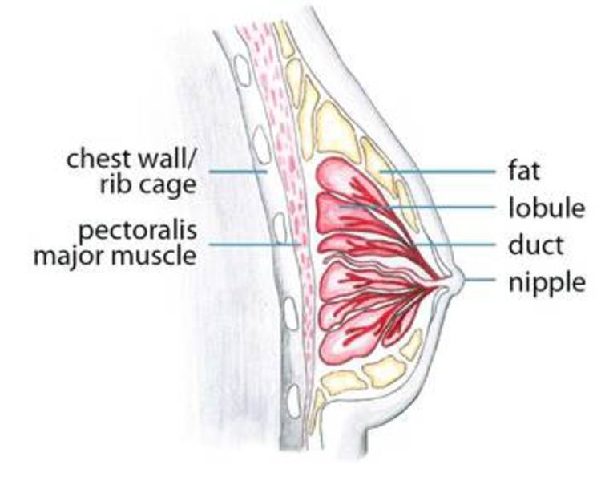

※ Ductal :(인체나 식물의)도관  
※ Lobular : 소엽의,뇌엽

TCGA focused mainly on two types of invasive breast cancer: ductal carcinoma(도관암) and lobular carcinoma(뇌엽암).

Invasive ductal carcinoma 는 가장 흔한 유방암 type이다.  
It comprises about 65–85% of all breast cancer and develops in the milk ducts of the breast.

About 10% of all cases of advanced breast cancer 2 are invasive lobular breast carcinoma.  
This cancer develops in the breast milk-producing lobules or glands.

[breast cancer 설명 출처](https://www.bebig.com/home/patients/breast_cancer/)  
[TCGA’s Study of Breast Ductal Carcinoma](https://www.cancer.gov/about-nci/organization/ccg/research/structural-genomics/tcga/studied-cancers/breast-ductal)

# 관련자료

## Paper

[Classifying Breast Cancer Subtypes Using Multiple Kernel Learning Based on Omics Data](https://www.ncbi.nlm.nih.gov/pmc/articles/PMC6471546/#B33-genes-10-00200)

**Omics** : 전체를 뜻하는 말인 `옴(-ome)`과 학문을 뜻하는 접미사 `익스(-ics)`가 결합된 말로, 어떤 특정 학문 분야를 말하기보다는 개별 유전자(gene), 전사물(transcript), 단백질(protein), 대사물(metabolite) 연구에 대비되는 **총체적인 개념의 데이터 세트를 바탕으로 하는 생물학 분야**

### Abstract

유방암 아형의 본질적인 차이를 탐구하는 것은 매우 중요  
본질적인 차이는 임상 진단 및 치료 계획의 지정과 밀접하게 관련

생물학적, 의학적 데이터세트가 축적되면서 다양한 측면에서 볼 수 있는 여러 가지 Omics data가 존재  
이런 데이터를 결합하면 예측의 정확성을 향상시킬 수 있음

**에스트로겐 수용체(ER)**, **프로게스테론 수용체(PR)**, **사람 표피성장인자 수용체2(HER2)**를 사용하여 유방암 아형을 정의

TCGA로부터 `mRNA data`, `methylation data` and `copy number variation (CNV) data`를 수집해 유방암 아형을 분류

다중 커널 학습(MKL)로 3개의 Omics data를 사용한 결과는 여러 개의 커널에 단일 Omics data를 사용한 결과보다 낫다.  
실험에서 제안된 방법은 다른 최첨단 방법보다 뛰어나며 풍부한 생물학적 해석을 가지고 있다.

### Introduction

더욱이 유방암을 앓고 있는 젊은 여성은 삼중 음성이나 HER2 양성 유방암과 같이 보다 공격적인 아형을 갖게 될 가능성이 높으며, 고도 단계로 식별될 가능성이 더 높다

종양 분자 타이핑의 개념은 1999년 국립 암 연구소에 의해 제안

- 미국 스탠퍼드대 페루 외 연구진은 2000년 유방암의 분자분류를 처음 보고
  - basal-like subtype, human epidermal growth subtype and normal breast-like subtype 등 4가지 1차 아형이 있다고 결론
- 2003년, Sorlie 외는 추가로 Luminal 하위 유형을 Luminal A와 Luminal B로 나눔눔

유방암의 아형을 규정하는 다른 분류방법이 많지만, 여전히 가장 널리 알려진 방법은 페루와 설리가 제안한 방법

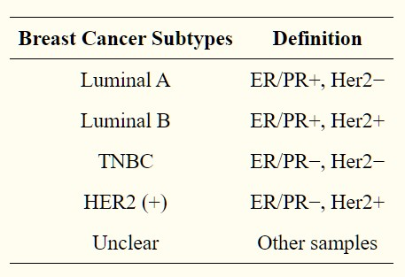

TNBC: 삼중음성 유방암; HER2: 사람 표피증식인자수용체 2

- The Unclear subtypes was the patients which have missing data in ER, PR or HER2
- Luminal A is the most common subtype of breast cancer in clinic, and it is usually an early form of breast cancer.
  - the 5-year local recurrence rate of this subtype is significantly lower than other subtypes
- the expression of hormone in patients with Luminal B is lower than Luminal A, while the expression of proliferation markers and histologic grade are higher than Luminal A
- Probably 25% of breast cancer are classified as HER2-positive, and this subtype has always been related to poor prognosis.
- Basle-like/TNBC is currently the most studied subtype, is easy to deteriorate and metastasize, is highly sensitive to chemotherapy

많은 유방암 subtype 분류에 대한 연구들이 있다.  
hierarchical clustering에 의해 gene expression patterns의 차이에 기초해 유방암 유형을 분리

SVM : 지도학습모형, 데이터 특징을 선형적으로 분리할 수 있는 더 높은 차원에 매핑한 커널 함수를 통해 비선형 분리 문제를 효과적으로 해결

클래식한 커널함수는 linear kernel, polynomial kernel, gaussian kernel이 존재  
이 후, Multiple kernel learining(MKL)을 등장하여 svm의 분류 정확도를 향상시킴

**우리는 SMO-MKL을 사용할 것(이 방법은 MKL을 사용하는 것보다 더 나을 결과를 도출)**

- SMO-MKL is an improved supervised method based on linear MKL framework fusing heterogeneous omics data of breast cancer from the Cancer Genome Atlas (TCGA)
1. mRNA, DNA methylation, Copy Number Variation(CNV)데이터를 수집하고 이러한 Omics 데이터와 subtypes(아형) 정보를 동시에 가진 환자들만 선택
2. 이 데이터들을 삭제하고 정규화. Omics 데이터에서 쓸모없느 문제를 해결하기 위해 각각 omics 데이터에 기초해 gene feature selection방법을 사용
3. 그 다음의 모형의 인풋으로 omics 데이터를 사용해 커널을 생성. 그리고 SMO-MKL 모형을 만들어 예측의 분류결과를 얻음

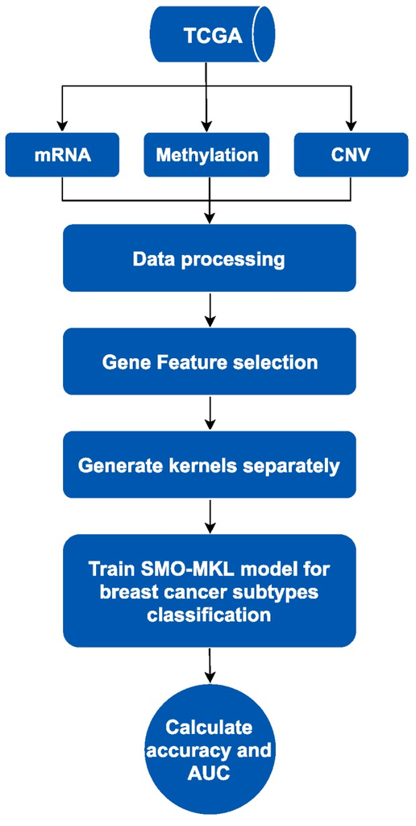

### Method

mRNA, DNA methylation, Copy number variation 데이터 사용 : 환자 샘플에서 동시에 측정

- the RNA sequencing level 3 data as mRNA data
- DNA Methylation 450k level 3 data as DNA methylation data
- the Affymetrix SNP 6.0 array data with GRCH 38 (hg38) genome data as CNV data.

clinical data로부터 ER, PR and Her2의 정보 사용하여 환자의 암 subtype을 확인

유방암 별개의 환자 샘플 606명이 포함된 데이터셋은 5개의 subtypes으로 나뉨

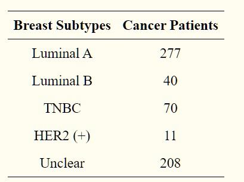

TNBC: 삼중음성 유방암; HER2: 사람 표피증식인자수용체 2

### Result

heatmap을 통해 살펴보니 3개의 데이터 중에서는 mRNA데이터에서 유방암 subtypes들이 가장 뚜렷히 분류가 되었다.

random forest, Neural network보다 SMO-MKL의 성능이 더 좋았다.

## Different Gene Expression

### Abstract

Bioconductor packages를 이용하여 RNA-seq differential gene expression을 살펴본다.  
gene-level의 count dataset을 이용한다.

### Introduction

Bioconductor packages는 많은 것을 할 수 있다.  
DESeq2패키지로 분석이 가능

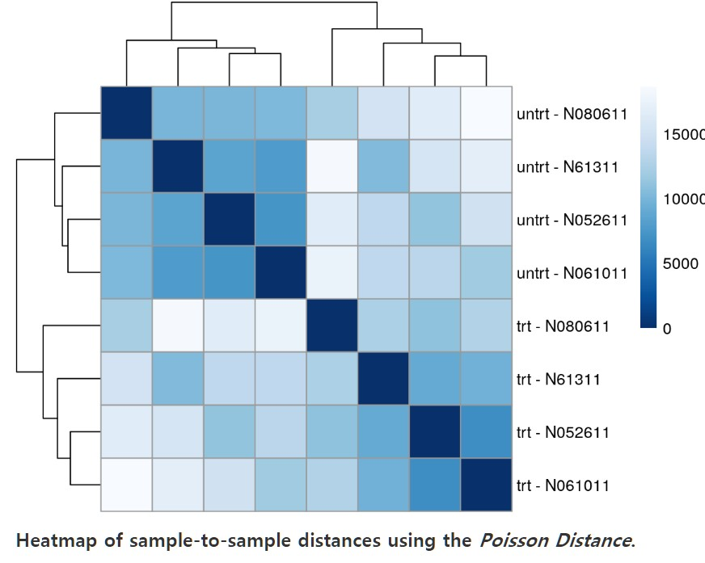

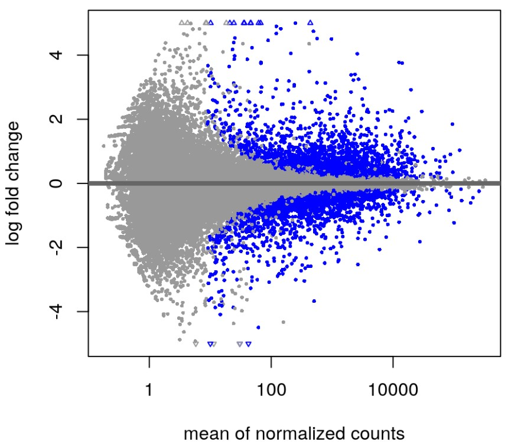

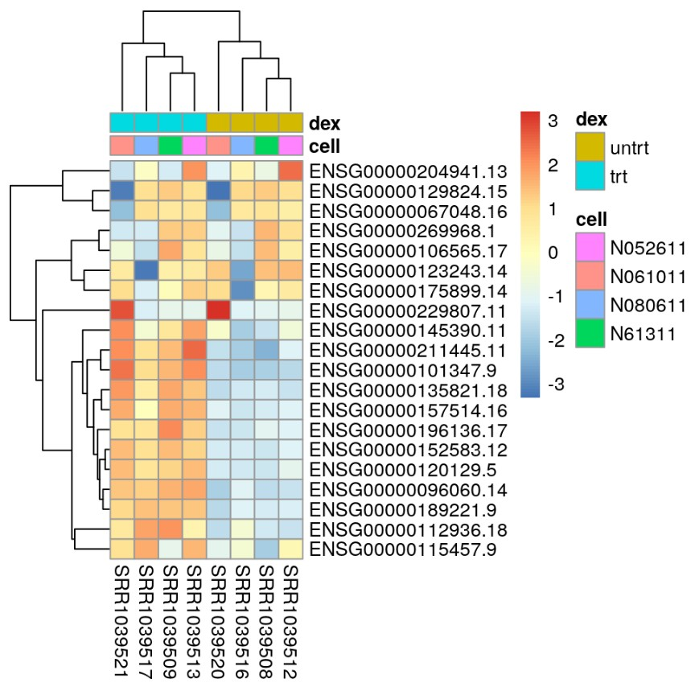

## 나의 생각?

1. mRNA데이터를 통해 유방암 subtype들의 different expression gene을 분석
2. tumor 4가지의 subtype에 대한 QC이 후, DEG를 수행하고 해석도 고려

tumor의 subtype을 분류하는 모형을 구축함에 있어서 DEG나 다른 방법을 통해 발현적으로 유의한 gene들만 선택하는 등 feature selection에 이용할 수도 있을 것

- subtype의 DEG수행 후 특징살피기
- 유방암 subtype에 영향을 미치는 유전자 탐색
- 이 유전자로부터 subtype들의 분류

# Data import & Pre-processing

## Library

```r
# Data manipulation
library(tidyverse)
library(data.table)
library(plyr)
library(stringr)

library(DT)


# Bio

# BiocManager::install("DESeq2")
# BiocManager::install("DEGseq")

library(BiocManager)
library(DEGseq) # not use
library(DESeq2) # I use this package
library(TCGAbiolinks)


# Visualization
library(patchwork)
library(ggthemes)
```

### function

```r
`%notin%` <- Negate(`%in%`)
```

사용자 부정 명령어를 할당

## Download the mRNA - count

```r
query <- GDCquery(project="TCGA-BRCA",
                  data.category="Transcriptome Profiling",
                  data.type="Gene Expression Quantification",
                  workflow.type="HTSeq - Counts")


# 2. Download from GDC repository
GDCdownload(query)


# 3. Make R object from the downloaded data
data <- GDCprepare(query)

# 4. Extract Gene expression matrix
library(SummarizedExperiment)

eset <- assay(data)
```

| Function | Description |
| --- | --- |
| TCGAquery_clinic() | Get the clinical information |
| TCGAquery() | TCGA open-access data providing also latest version of the files. |
| dataBRCA() | TCGA data matrix BRCA |

[Function Description](https://www.rdocumentation.org/packages/TCGAbiolinks/versions/1.2.5)

## Import data

```r
normal <- eset %>% data.frame

data <- fread("./data/brca_tcga_pub/data_clinical_sample.txt",
              data.table = F)

patient <-
  data %>%
  dplyr::select(`Patient Identifier`, `ER Status`, `PR Status`, `HER2 Status`) %>%
  filter(`ER Status` %in% c("Positive","Negative") &
           `PR Status` %in% c("Positive","Negative") &
           `HER2 Status` %in% c("Positive","Negative"))
```

### naming match

```r
library(biomaRt)

ensembl_ids <- unlist(lapply(rownames(normal), as.character), use.names=FALSE)


ens <- useEnsembl(biomart="ensembl",
                  dataset="hsapiens_gene_ensembl")


genes.tbl <- getBM(attributes = c("ensembl_gene_id","hgnc_symbol"),
                   filters = "ensembl_gene_id",
                   values = ensembl_ids,
                   mart = ens)


# head(genes.tbl)
# duplicated(genes.tbl$ensembl_gene_id) %>% sum
# duplicated(genes.tbl$hgnc_symbol) %>% sum
```

유전자에 이름을 부여하고 난 뒤에는 18893개가 중복되었다. 중복된 것들은 삭제하고 진행한다.

```r
genes.tbl <-
genes.tbl[!duplicated(genes.tbl$hgnc_symbol) &!duplicated(genes.tbl$ensembl_gene_id), ]

genes.tbl %>% dim
```

```
## [1] 37600     2
```

```r
genes.tbl %>% head
```

```
##   ensembl_gene_id hgnc_symbol
## 1 ENSG00000000003      TSPAN6
## 2 ENSG00000000005        TNMD
## 3 ENSG00000000419        DPM1
## 4 ENSG00000000457       SCYL3
## 5 ENSG00000000460    C1orf112
## 6 ENSG00000000938         FGR
```

```r
rownames(normal) %in% genes.tbl$ensembl_gene_id %>% sum
```

```
## [1] 37600
```

```r
normal <- normal[rownames(normal) %in% genes.tbl$ensembl_gene_id,]
```

```r
normal[1:5,1:2]
```

```
##                 TCGA.E9.A1NF.01A.11R.A14D.07 TCGA.D8.A27M.01A.11R.A16F.07
## ENSG00000000003                          952                         2511
## ENSG00000000005                            2                           40
## ENSG00000000419                         1041                         1455
## ENSG00000000457                          906                         1978
## ENSG00000000460                          289                          725
```

```r
all(rownames(normal)==genes.tbl$ensembl_gene_id)
```

```
## [1] TRUE
```

```r
rownames(normal) <- genes.tbl$hgnc_symbol

normal[1:5,1:2]
```

```
##          TCGA.E9.A1NF.01A.11R.A14D.07 TCGA.D8.A27M.01A.11R.A16F.07
## TSPAN6                            952                         2511
## TNMD                                2                           40
## DPM1                             1041                         1455
## SCYL3                             906                         1978
## C1orf112                          289                          725
```

### patient

|  | Patient Identifier | ER Status | PR Status | HER2 Status |
| --- | --- | --- | --- | --- |
| 1 | TCGA-A2-A0T2-01 | Negative | Negative | Negative |
| 2 | TCGA-A2-A04P-01 | Negative | Negative | Negative |
| 3 | TCGA-A1-A0SK-01 | Negative | Negative | Negative |
| 4 | TCGA-A2-A0CM-01 | Negative | Negative | Negative |
| 5 | TCGA-AR-A1AR-01 | Negative | Negative | Negative |
| 6 | TCGA-B6-A0WX-01 | Negative | Negative | Negative |
| 7 | TCGA-BH-A18V-01 | Negative | Negative | Negative |
| 8 | TCGA-BH-A18Q-01 | Negative | Negative | Negative |
| 9 | TCGA-BH-A18K-01 | Positive | Positive | Negative |
| 10 | TCGA-BH-A0HL-01 | Positive | Positive | Negative |

[output cut: 718 more lines]

### normal

|  | TCGA.E9.A1NF.01A.11R.A14D.07 | TCGA.D8.A27M.01A.11R.A16F.07 | TCGA.BH.A0GZ.01A.11R.A056.07 |
| --- | --- | --- | --- |
| TSPAN6 | 952 | 2511 | 2095 |
| TNMD | 2 | 40 | 19 |
| DPM1 | 1041 | 1455 | 1680 |
| SCYL3 | 906 | 1978 | 960 |
| C1orf112 | 289 | 725 | 397 |

## Pre-Process

### normal data

```r
normal[1:3,1:3]
```

```
##        TCGA.E9.A1NF.01A.11R.A14D.07 TCGA.D8.A27M.01A.11R.A16F.07
## TSPAN6                          952                         2511
## TNMD                              2                           40
## DPM1                           1041                         1455
##        TCGA.BH.A0GZ.01A.11R.A056.07
## TSPAN6                         2095
## TNMD                             19
## DPM1                           1680
```

```r
normal <- normal[, str_sub(colnames(normal), 14,15) == "01"]

colnames(normal) <- str_sub(colnames(normal),1,15)
colnames(normal) <- gsub(pattern = ".",replacement = "-",
                         x = colnames(normal), fixed = T)


normal %>% dim
```

```
## [1] 37600  1102
```

```r
normal <- normal[, !duplicated(colnames(normal))]

normal %>% dim
```

```
## [1] 37600  1091
```

|  | TCGA-E9-A1NF-01 | TCGA-D8-A27M-01 |
| --- | --- | --- |
| TSPAN6 | 952 | 2511 |
| TNMD | 2 | 40 |
| DPM1 | 1041 | 1455 |
| SCYL3 | 906 | 1978 |
| C1orf112 | 289 | 725 |

tumor인 사람만 고른 후, patient의 rownames이름 형식과 맞추기 위한 작업을 한다.  
단 normal데이터에서 뒤를 날렸기 때문에 중복된 이름이 존재할 수 있다. 이 부분은 그냥 감안하고 중복된 사람은 없애기로 한다.

### patient data

```r
colnames(patient) <- c("sample","ER","PR","HER2")


patient <-
  patient %>% mutate(condition = case_when(
    ER == "Positive" & PR == "Positive" & HER2 == "Negative" ~ "LuminalA",
    ER == "Positive" & PR == "Positive" & HER2 == "Positive" ~ "LuminalB",
    ER == "Negative" & PR == "Negative" & HER2 == "Negative" ~ "TNBC",
    ER == "Negative" & PR == "Negative" & HER2 == "Positive" ~ "HER2"))

patient <- patient %>% arrange(condition)
patient <- patient %>% filter(!is.na(condition))

patient %>% head
```

```
##            sample       ER       PR     HER2 condition
## 1 TCGA-A2-A0T1-01 Negative Negative Positive      HER2
## 2 TCGA-BH-A0EE-01 Negative Negative Positive      HER2
## 3 TCGA-A2-A0D1-01 Negative Negative Positive      HER2
## 4 TCGA-A2-A04W-01 Negative Negative Positive      HER2
## 5 TCGA-AO-A12D-01 Negative Negative Positive      HER2
## 6 TCGA-AO-A0JE-01 Negative Negative Positive      HER2
```

```r
patient <- column_to_rownames(patient, "sample")

patient %>% head
```

```
##                       ER       PR     HER2 condition
## TCGA-A2-A0T1-01 Negative Negative Positive      HER2
## TCGA-BH-A0EE-01 Negative Negative Positive      HER2
## TCGA-A2-A0D1-01 Negative Negative Positive      HER2
## TCGA-A2-A04W-01 Negative Negative Positive      HER2
## TCGA-AO-A12D-01 Negative Negative Positive      HER2
## TCGA-AO-A0JE-01 Negative Negative Positive      HER2
```

```r
normal <- normal[, colnames(normal) %in% rownames(patient)]
patient <- patient[rownames(patient) %in% colnames(normal), ]

dim(normal); dim(patient)
```

```
## [1] 37600   630
```

```
## [1] 630   4
```

공통으로 들어간 환자로 일치시킨다.

### Match

```r
match(rownames(patient), colnames(normal)) %>% is.na %>% sum
```

```
## [1] 0
```

```r
match_idx <- match(colnames(normal), rownames(patient))
meta_dat <- patient[match_idx,]

meta_dat[1:3, ]
```

```
##                       ER       PR     HER2 condition
## TCGA-E9-A1NF-01 Positive Positive Negative  LuminalA
## TCGA-D8-A27M-01 Negative Negative Negative      TNBC
## TCGA-BH-A0GZ-01 Positive Positive Negative  LuminalA
```

```r
normal[1:3, 1:3]
```

```
##        TCGA-E9-A1NF-01 TCGA-D8-A27M-01 TCGA-BH-A0GZ-01
## TSPAN6             952            2511            2095
## TNMD                 2              40              19
## DPM1              1041            1455            1680
```

```r
all(rownames(meta_dat) == colnames(normal))
```

```
## [1] TRUE
```

```r
meta_dat <- meta_dat %>% dplyr::select(condition)

meta_dat %>% head
```

```
##                 condition
## TCGA-E9-A1NF-01  LuminalA
## TCGA-D8-A27M-01      TNBC
## TCGA-BH-A0GZ-01  LuminalA
## TCGA-BH-A18V-01      TNBC
## TCGA-A7-A13G-01  LuminalA
## TCGA-BH-A0GY-01  LuminalA
```

```r
normal[1:3, 1:3]
```

```
##        TCGA-E9-A1NF-01 TCGA-D8-A27M-01 TCGA-BH-A0GZ-01
## TSPAN6             952            2511            2095
## TNMD                 2              40              19
## DPM1              1041            1455            1680
```

DESeq2모형에 탑재하기 위해서는 환자의 순서를 통일해준다.

#### subtype count

| condition | n |
| --- | --- |
| HER2 | 30 |
| LuminalA | 418 |
| LuminalB | 60 |
| TNBC | 122 |

#### NA count

```r
map_dbl(meta_dat, ~sum(is.na(.x)))
```

```
## condition
##         0
```

```r
map_dbl(normal, ~sum(is.na(.x))) %>% sum
```

```
## [1] 0
```

두 데이터에서 서로 없는 부분이 존재하면 NA가 생기고 sum결과 연산이 되지 않아 NA가 발생할 것  
여기서는 0으로 모두 공통으로 존재함

```r
# arrange_index <-
# meta_dat %>%rownames_to_column(var = "gene") %>%
#   arrange(condition) %>%
#   column_to_rownames(var = "gene") %>%
#   rownames %>%
#   match(colnames(normal))
#
# meta_dat <-
# meta_dat %>%rownames_to_column(var = "gene") %>%
#   arrange(condition) %>%
#   column_to_rownames(var = "gene")
#
# normal <- normal[,arrange_index]
# all(rownames(meta_dat)==colnames(normal))
```

# Unsupervised learning

```r
dds <- DESeqDataSetFromMatrix(countData = normal,
                              colData = meta_dat,
                              design = ~ condition)
dds


dds_fac <- estimateSizeFactors(dds)
# sizeFactors(dds_fac)


normalized_counts <- counts(dds_fac, normalized=TRUE)
# View(normalized_counts)

vsd <- vst(dds_fac, blind=TRUE)

# Extract the vst matrix from the object
vsd_mat <- assay(vsd)

# Compute pairwise correlation values
vsd_cor <- cor(vsd_mat)
```

## Headmap

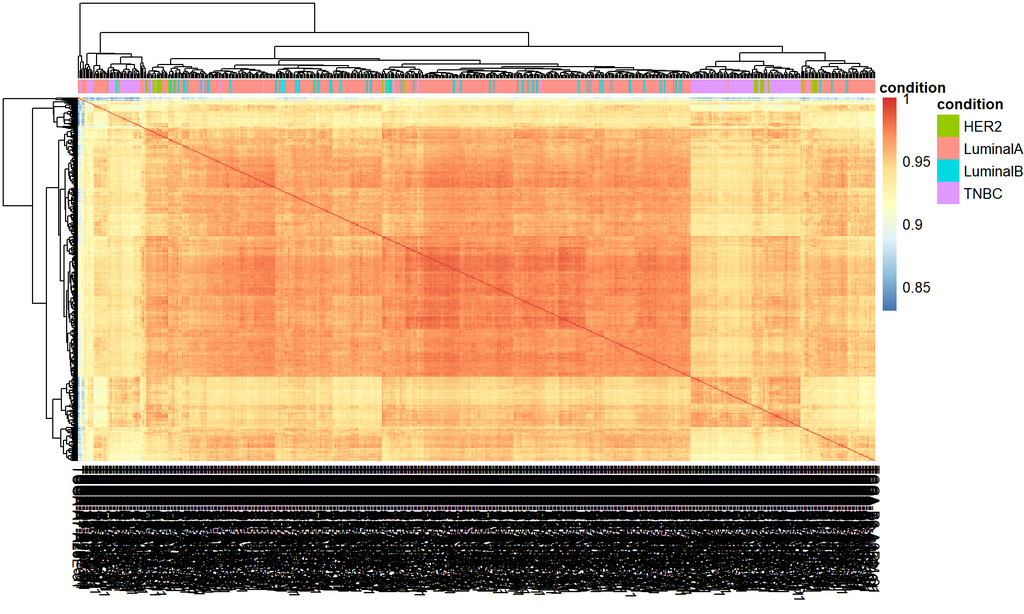

```r
# Load pheatmap libraries
library(pheatmap)
# Plot heatmap
pheatmap(vsd_cor,
         cluster_rows = T,
         show_rownames = F,
         annotation = dplyr::select(meta_dat, condition))
```

## PCA

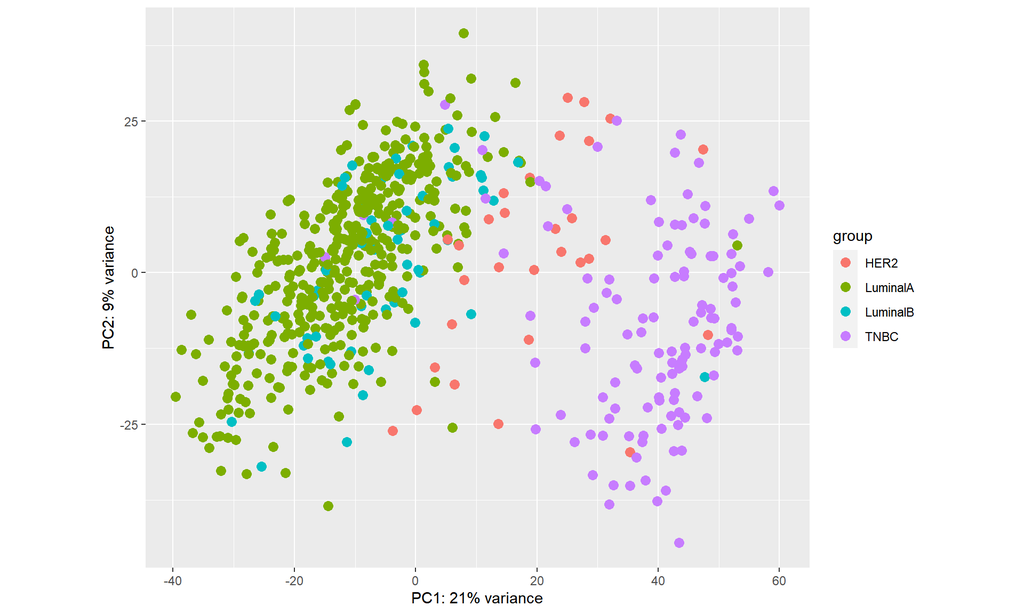

```r
# Plot PCA
plotPCA(vsd, intgroup="condition")
```

# DEG analysis

```r
# HER2 vs LuminalA

her2_luminalA_meta_dat <-
  meta_dat %>%
  mutate(number=1:nrow(meta_dat)) %>%
  filter(condition %in% c("LuminalA","HER2"))

her2_luminalA_normal <-
  normal %>%
  dplyr::select(her2_luminalA_meta_dat$number)

all(rownames(her2_luminalA_meta_dat)==colnames(her2_luminalA_normal))
```

```
## [1] TRUE
```

```r
# # HER2 vs Luminal B
#
# her2_luminalB_meta_dat <-
#   meta_dat %>%
#   mutate(number=1:nrow(meta_dat)) %>%
#   filter(condition %in% c("LuminalB","HER2"))
#
# her2_luminalB_normal <-
#   normal %>%
#   dplyr::select(her2_luminalB_meta_dat$number)
#
# all(rownames(her2_luminalB_meta_dat)==colnames(her2_luminalB_normal))
#
#
#
# # HER2 vs TNBC
#
# her2_TNBC_meta_dat <-
#   meta_dat %>%
#   mutate(number=1:nrow(meta_dat)) %>%
#   filter(condition %in% c("TNBC","HER2"))
#
# her2_TNBC_normal <-
#   normal %>%
#   dplyr::select(her2_TNBC_meta_dat$number)
#
# all(rownames(her2_TNBC_meta_dat)==colnames(her2_TNBC_normal))
#
#
# # Luminal A vs Luminal B
#
# luminalA_luminalB_meta_dat <-
#   meta_dat %>%
#   mutate(number=1:nrow(meta_dat)) %>%
#   filter(condition %in% c("LuminalA","LuminalB"))
#
# luminalA_luminalB_normal <-
#   normal %>%
#   dplyr::select(luminalA_luminalB_meta_dat$number)
#
# all(rownames(luminalA_luminalB_meta_dat)==colnames(luminalA_luminalB_normal))
#
#
# # Luminal A vs TNBC
#
# luminalA_TNBC_meta_dat <-
#   meta_dat %>%
#   mutate(number=1:nrow(meta_dat)) %>%
#   filter(condition %in% c("LuminalA","TNBC"))
#
# luminalA_TNBC_normal <-
#   normal %>%
#   dplyr::select(luminalA_TNBC_meta_dat$number)
#
# all(rownames(luminalA_TNBC_meta_dat)==colnames(luminalA_TNBC_normal))
#
# # Luminal B vs TNBC
#
# luminalB_TNBC_meta_dat <-
#   meta_dat %>%
#   mutate(number=1:nrow(meta_dat)) %>%
#   filter(condition %in% c("LuminalB","TNBC"))
#
# luminalB_TNBC_normal <-
#   normal %>%
#   dplyr::select(luminalB_TNBC_meta_dat$number)
#
# all(rownames(luminalB_TNBC_meta_dat)==colnames(luminalB_TNBC_normal))
```

각 비교할 type들의 유전자 쌍별로 데이터를 분리하여 DESeq2모형에 넣을 계획이다.

```r
# HER2 vs LuminalA
dds_HER2_luminalA <-
  DESeqDataSetFromMatrix(countData = her2_luminalA_normal,
                         colData = her2_luminalA_meta_dat,
                         design = ~ condition)
dds_HER2_luminalA <- estimateSizeFactors(dds_HER2_luminalA)


# # HER2 vs LuminalB
# dds_HER2_luminalB <-
#   DESeqDataSetFromMatrix(countData = her2_luminalB_normal,
#                          colData = her2_luminalB_meta_dat,
#                          design = ~ condition)
# dds_HER2_luminalB <- estimateSizeFactors(dds_HER2_luminalB)
#
#
# # HER2 vs TNBC
# dds_HER2_TNBC <-
#   DESeqDataSetFromMatrix(countData = her2_TNBC_normal,
#                          colData = her2_TNBC_meta_dat,
#                          design = ~ condition)
# dds_HER2_TNBC <- estimateSizeFactors(dds_HER2_TNBC)
#
#
# # LuminalA vs LuminalB
# dds_luminalA_luminalB <-
#   DESeqDataSetFromMatrix(countData = luminalA_luminalB_normal,
#                          colData = luminalA_luminalB_meta_dat,
#                          design = ~ condition)
# dds_luminalA_luminalB <- estimateSizeFactors(dds_luminalA_luminalB)
#
#
#
# # LuminalA vs TNBC
# dds_luminalA_TNBC <-
#   DESeqDataSetFromMatrix(countData = luminalA_TNBC_normal,
#                          colData = luminalA_TNBC_meta_dat,
#                          design = ~ condition)
# dds_luminalA_TNBC <- estimateSizeFactors(dds_luminalA_TNBC)
#
#
#
# # LuminalB vs TNBC
# dds_luminalB_TNBC <-
#   DESeqDataSetFromMatrix(countData = luminalB_TNBC_normal,
#                          colData = luminalB_TNBC_meta_dat,
#                          design = ~ condition)
# dds_luminalB_TNBC <- estimateSizeFactors(dds_luminalB_TNBC)
```

```r
# Run analysis
dds_HER2_luminalA_model <- DESeq(dds_HER2_luminalA)

# dds_HER2_luminalB_model <- DESeq(dds_HER2_luminalB)
#
# dds_HER2_TNBC_model <- DESeq(dds_HER2_TNBC)
#
# dds_luminalA_luminalB_model <- DESeq(dds_luminalA_luminalB)
#
# dds_luminalA_TNBC_model <- DESeq(dds_luminalA_TNBC)
#
# dds_luminalA_TNBC_model <- DESeq(dds_luminalB_TNBC)
```

## HER2 vs Luminal A

쌍별 유전자 차이에 대한 검정을 하나만 예로 실행해보자.

```r
result_HER2_luminalA <-
  results(dds_HER2_luminalA_model,
          contrast = c("condition", "HER2", "LuminalA"),
          alpha = 0.05,
          lfcThreshold = 0.2)

# plotDispEsts(dds_HER2_luminalA_model)


mcols(result_HER2_luminalA)
```

```
## DataFrame with 6 rows and 2 columns
##                        type                                        description
##                 <character>                                        <character>
## baseMean       intermediate          mean of normalized counts for all samples
## log2FoldChange      results log2 fold change (MLE): condition HER2 vs LuminalA
## lfcSE               results         standard error: condition HER2 vs LuminalA
## stat                results         Wald statistic: condition HER2 vs LuminalA
## pvalue              results      Wald test p-value: condition HER2 vs LuminalA
## padj                results                               BH adjusted p-values
```

```r
result_HER2_luminalA
```

[output not shown]

| **baseMean** | mean value across all the samples |
| --- | --- |
| **lfcSE** | standard error of the fold change estimates |
| **stat** | wald statistics output from the wald test for differential expression |
| **pvalue** | the wald test p-value |
| **padj** | the Benjamini-Hochberg adjusted p-value |

```r
summary(result_HER2_luminalA)
```

```
##
## out of 36508 with nonzero total read count
## adjusted p-value < 0.05
## LFC > 0.20 (up)    : 3059, 8.4%
## LFC < -0.20 (down) : 3093, 8.5%
## outliers [1]       : 0, 0%
## low counts [2]     : 9188, 25%
## (mean count < 0)
## [1] see 'cooksCutoff' argument of ?results
## [2] see 'independentFiltering' argument of ?results
```

log fold change가 threshold보다 큰 값과 작은 값 등을 나타낸다.

true positives또는 DE라고 불리는 유전자를 잘못된 것으로부터 구별하는 방법은 어려운데, DESeq2는 Benjamini-Hochberg(BH-method) 방법으로 p-value를 조정하고, true positive에 대해 false positive를 제어하기 위해 multiple test correction을 수행한다.

DESeq2는 모든 표본에 걸쳐 zero counts인 유전자, 평균값이 낮은 유전자, extreme 값을 가지는 outlier를 가진 유전자 등 testing전에 실제로 다르게 표현될 가능성이 없는 유전자들을 자동으로 걸러낸다.

`summary()`를 통해 alpha level에 대해 차이를 보이는 유전자의 수와 필터링된 유전자의 수에 대한 정보를 확인할 수 있다.

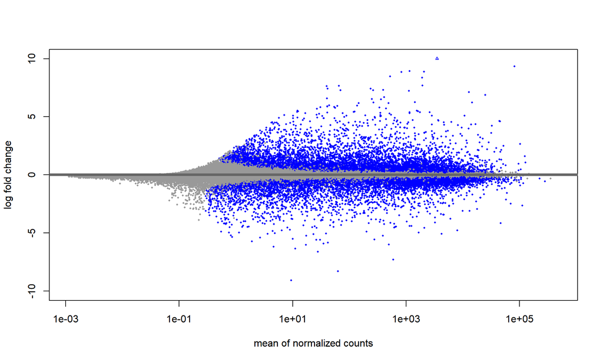

```r
p1 <-
result_HER2_luminalA %>%
  data.frame %>%
  rownames_to_column(var = "gene") %>%
  mutate(threshold = padj < 0.05) %>%
  filter(threshold %notin% NA) %>%

  ggplot(aes(x = log2FoldChange, y = -log10(padj),
             color = threshold)) +
  theme_classic() +
  geom_point() +
  xlab("log2 fold chage") +
  ylab("-log10 adjusted p-value") +
  theme(legend.position = c(0.2,0.8),
        legend.background = element_rect(linetype = "solid",
                                         size = 0.5,
                                         colour = "darkblue"),
        plot.title = element_text(size = rel(1.5), hjust = 0.5),
        axis.title = element_text(size = rel(1.25))) +
  scale_x_continuous(breaks = seq(-12,10,2))


p2 <-
result_HER2_luminalA %>%
  data.frame %>%
  rownames_to_column(var = "gene") %>%
  mutate(threshold = padj < 0.05) %>%
  filter(threshold %notin% NA) %>%

  ggplot(aes(x = log2FoldChange, y = -log10(padj),
             color = threshold)) +
  theme_classic() +
  geom_point() +
  xlab("log2 fold chage") +
  ylab("") +
  theme(legend.position = "none") +
  coord_cartesian(xlim=c(-5, 5),ylim=c(0,25))




plotMA(dds_HER2_luminalA_model, ylim = c(-10,10))
```

MA plot은 유전체 데이터의 시각적 표현을 위해 Bland-Altman plot을 적용한 것

데이터를 M(로그 비율)와 A(mean average)로 변환한 다음 이러한 값을 표시하여 두 표본에서 측정한 측정값 간의 차이를 시각화한다. 원래 두 채널 DNA 마이크로어레이 유전자 발현 데이터의 맥락에서 적용되었지만, MA 플롯은 high-throughput sequencing analysis을 시각화하는 데도 사용된다. MA plot은 expression change와 condition의 차이에 대한 관계(log ratio, M), 유전자의 평균 변화 강도 그리고 유전자 차이 표현을 감지하는 알고리즘을 전반적으로 제공한다.  
유의한 임계값을 통과한 유전자는 파란색으로 표시된다.

> 분석 화학 또는 생물 의학에서의 Bland-Altman plot(difference plot)은 서로 다른 두 분석 사이의 합치를 분석하는 데 사용되는 data plotting 방법이다.  
> 다른 분야에서 알려진 이름인 Tukey mean-difference plot과 동일하지만, Martin Bland와 Douglas G.Altman에 의해 의료 통계에 대중화되었다.

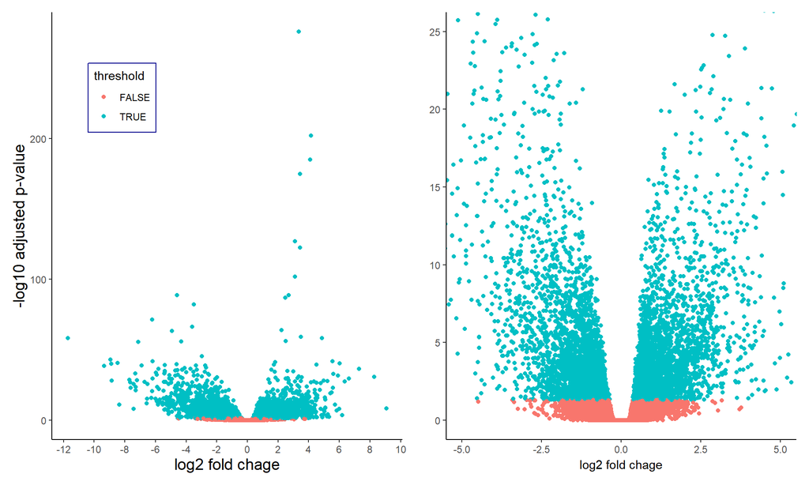

```r
p1 + p2
```

Fold change : 어떤 유전자에 대하여 실험군에서의 평균발현량이 대조군에서의 평균발현량의 몇 배인지를 나타냄  
P-value : 두 군의 평균발현량 차이가 통계적으로 유의미한 값인지를 알려줌.

Volcano plot : Log-scaled fold-change를 X축, -Log-scaled P-value를 Y축으로 갖는 그래프로, 그 모습이 화산 폭발과 비슷하여 볼케이노 플롯이라고 불린다.

0.05를 threshold로 잡고 유의미한 유전자와 아닌 유전자를 색으로 표현  
오른쪽 그림은 왼쪽 전체그림 중 중요한 부분만 확대하여 확인한 것

# 연구와는 무관한 필요없는 내용

limma, DEseq 또는 DESeq2패키지로 유전자 발현에 대한 차이를 분석할 수 있다.

```r
# str_locate(dataBRCA %>% names, "\\d\\dA")

# str_sub(dataBRCA %>% names,start = 14, end=16)
# index <- str_sub(dataBRCA %>% names,start = 14, end=16)=="01A"
#
#
# cancer <- dataBRCA[,index]
# normal <- dataBRCA[,!index]
```

```r
# str_sub(koo %>% names,start = 14, end=16)
# cancer_index <- str_sub(koo %>% names,start = 14, end=15)=="01"
# normal_index <- str_sub(koo %>% names,start = 14, end=15)=="11"
#
# cancer <- koo[,cancer_index]
# normal <- koo[,normal_index]
```

```r
# DEGexp(geneExpMatrix1 = normal, geneCol1 = 1, groupLabel1 = "Normal",
#        geneExpMatrix2 = cancer, geneCol2 = 1, groupLabel2 = "Cancer",
#        method="MARS", output='output')
```

```r
# output <- fread("./output/output_score.txt")
#
# head(output)
```

```r
# 유전자 이름? 이름이 TCGA랑 다름
# devtools::install_github("stephenturner/annotables")

# library(annotables)
```

# Refer

- [TCGAbiolinks 대략적인 설명 블로그](http://www.incodom.kr/TCGAbiolinks#h_04b78a38c44c25698b471e7ea22434eb)
- [Broad Institute GDAC Firehose](https://m.blog.naver.com/PostView.nhn?blogId=cjh226&logNo=220868113892&proxyReferer=https:%2F%2Fwww.google.com%2F)
- [TCGA Barcode 의미](http://blog.naver.com/PostView.nhn?blogId=cjh226&logNo=220992617831&parentCategoryNo=&categoryNo=18&viewDate=&isShowPopularPosts=false&from=postView)
- [DEG 설명 블로그](https://sosal.kr/848)
- [biomaRt네이버 블로그](https://m.blog.naver.com/PostView.nhn?blogId=cjh226&logNo=221398384399&targetKeyword=&targetRecommendationCode=1)
- [biomaRt구글링](https://www.bioconductor.org/packages/devel/bioc/vignettes/biomaRt/inst/doc/accessing_ensembl.html)

간접적 도움 읽어본 자료

- [Remove rows with all or some NAs in data.frame](https://stackoverflow.com/questions/4862178/remove-rows-with-all-or-some-nas-missing-values-in-data-frame)
- [TCGA BRCA - SOX10](https://www.biostars.org/p/381632/)
- [Matched Paired Tumour-Normal DEA of BRCA using data downloaded using TCGAbiolinks](https://www.biostars.org/p/321918/)
- [Differential Expression and Visualization in R](https://angus.readthedocs.io/en/2019/diff-ex-and-viz.html#differential-expression-with-deseq2)
- [R&DESeq2 - Volcano plot 네이버 블로그](http://blog.naver.com/PostView.nhn?blogId=cjh226&logNo=221360753408&parentCategoryNo=&categoryNo=18&viewDate=&isShowPopularPosts=false&from=postList)
- [TCGA Workflow: Analyze cancer genomics and epigenomics data using Bioconductor packages](https://bioconductor.org/packages/devel/workflows/vignettes/TCGAWorkflow/inst/doc/TCGAWorkflow.html#abstract)
- [Introduction to DGE](https://hbctraining.github.io/DGE_workshop/lessons/05_DGE_DESeq2_analysis2.html)
- [Using DESeq2 for gene-level differential expression analysis - GITHUB](https://github.com/hbctraining/DGE_workshop/blob/master/exercises/DGE_analysis_exercises%20answer_key.md)
- [workflow in DESeq2](http://bioconductor.org/packages/devel/bioc/vignettes/DESeq2/inst/doc/DESeq2.html)